# R Notebook

This is a [R Notebook](http://rmarkdown.rstudio.com) for the “Introducton to R and R Studio” UMN Data Management Bootcamp workshop. Slides and data can be found [here](http://z.umn.edu/rtutorial).

# Objectives

```
    - Exploring RStudio
    - Setting up a new project
    - Getting data into R as a CSV file
    - Exploring your data & getting summary statistics
    - Plotting Your Data
    - Get data out of R as a CSV file
```

# Aside: What is an RNotebook (i.e. “What Am I Looking At?)

RNotebooks let you run R code and display the results while also sharing the results as an html file. We will be using this R Notebook to display code and examples. All the commands seen in the following snippits can be run in an R Script, the R console, or in a .R file

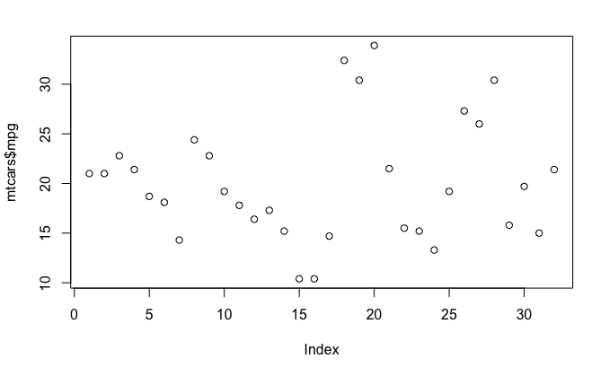

```r
plot(mtcars$mpg)
```

# Exploring RStudio

Things to point out: - File editing pane - Console/Terminal pane - Right panes (enviornment, information) - How to change settings (and themes)

More information we are going to skip over: - [Data Carpentry: Before We Start](http://datacarpentry.org/R-ecology-lesson/00-before-we-start.html)

# Seting up a new project

Using “File –> New Project” set up a new project in a new directory on your computer. This is where we will save our work (remember where this is so we can move data to it later).

## Create a new R Script

Open a new R Script file (File –> New File –> R Script) and save it in your working directory with a .R extention

## Set your working directory

This lets R know where it should look for and save files

This can be done by (Session –> Set Working Directory).

Then copy and paste the line that appears in your console to your script so it’s easy to run next time

```r
setwd("~/projects/TeachingRIntro50Minutes")
```

## Install any libraries you will need

This only needs to be done once for each install of R. This can take a lot of time if the package is large or has a lot of dependencies. In this case, let’s start by installing the ggplot2 package.

```r
install.packages("ggplot2")
```

## Load Libraries into memory.

This needs to be done each for each R session.

```r
library(ggplot2)
```

## ASIDE: Getting help inside R for any of the above commands

```r
?str
?read.csv
```

# Getting data into R

There a number of different ways to get data into R.

## Manually assigning variables

First, let’s assign some data, both numbers and text, to a couple different variable names.

ASIDE: R has a lot of different data structures and types that you will learn as you explore R and as you need to do different things with R.

```r
x <- 5
x
```

```
[1] 5
```

```r
y <- "Rstats"
y
```

```
[1] "Rstats"
```

```r
z <- c("rstats", "perl", "bash", "python")
z
```

```
[1] "rstats" "perl"   "bash"   "python"
```

## Built-in dataset that comes with R

R comes with a number or built-in datasets that are good for eploring R and R Studio. We can load them directly but we can also assign them to variable names.

|  | mpg | cyl | disp | hp | drat | wt | qsec | vs | am | gear | carb |
| --- | --- | --- | --- | --- | --- | --- | --- | --- | --- | --- | --- |
| Mazda RX4 | 21.0 | 6 | 160.0 | 110 | 3.90 | 2.620 | 16.46 | 0 | 1 | 4 | 4 |
| Mazda RX4 Wag | 21.0 | 6 | 160.0 | 110 | 3.90 | 2.875 | 17.02 | 0 | 1 | 4 | 4 |
| Datsun 710 | 22.8 | 4 | 108.0 | 93 | 3.85 | 2.320 | 18.61 | 1 | 1 | 4 | 1 |
| Hornet 4 Drive | 21.4 | 6 | 258.0 | 110 | 3.08 | 3.215 | 19.44 | 1 | 0 | 3 | 1 |
| Hornet Sportabout | 18.7 | 8 | 360.0 | 175 | 3.15 | 3.440 | 17.02 | 0 | 0 | 3 | 2 |
| Valiant | 18.1 | 6 | 225.0 | 105 | 2.76 | 3.460 | 20.22 | 1 | 0 | 3 | 1 |
| Duster 360 | 14.3 | 8 | 360.0 | 245 | 3.21 | 3.570 | 15.84 | 0 | 0 | 3 | 4 |
| Merc 240D | 24.4 | 4 | 146.7 | 62 | 3.69 | 3.190 | 20.00 | 1 | 0 | 4 | 2 |
| Merc 230 | 22.8 | 4 | 140.8 | 95 | 3.92 | 3.150 | 22.90 | 1 | 0 | 4 | 2 |
| Merc 280 | 19.2 | 6 | 167.6 | 123 | 3.92 | 3.440 | 18.30 | 1 | 0 | 4 | 4 |

[output cut: 22 more lines]

# Loading our own dataset (from .csv files) into R

the read.csv function will load a csv file into RStudio. It has a number of options.

```r
surveys <- read.csv("portal_data_joined.csv")
```

```
Error in read.table(file = file, header = header, sep = sep, quote = quote,  :
  no lines available in input
```

You can also download data directly from R, in this case from figshare:

```r
download.file("https://ndownloader.figshare.com/files/2292169", "portal_data_joined.csv")
```

# Exploring your data

## Look at the first couple rows of your data

|  | org_name | prop_name | public_private | address | zip_code | energy_star_score | prop_type | floor_area | floor_area_parking | year_built | total_GHG_emissions | site_EUI | weather_normalized_site_EUI | source_EUI | weather_normalized_source_EUI | water_use |
| --- | --- | --- | --- | --- | --- | --- | --- | --- | --- | --- | --- | --- | --- | --- | --- | --- |
| 1 | Hennepin County | 1800 Chicago | Public | 1800 Chicago S. | 55404 | 88 | Office | 102815 | NA | 1996 | 847 | 74 | 79 | 137 | 141 | 2574 |
| 2 | Hennepin County | Central Library | Public | 300 Nicolet Mall | 55401 | NA | Other | 406354 | 266266 | 2004 | 2971 | 48 | 50 | 115 | 118 | 7203 |
| 3 | Hennepin County | Century Plaza | Public | 330 south 12th st | 55404 | 98 | Office | 297650 | 194471 | 1934 | 2375 | 56 | 58 | 127 | 130 | 2876 |
| 4 | Hennepin County | Family Justice Center | Public | 110 S. 4th St. | 55415 | 97 | Courthouse | 227422 | 49804 | 1956 | 1516 | 53 | 56 | 109 | 111 | 1087 |
| 5 | Hennepin County | Forensic Sciences Building | Public | 530 Chicago Avenue South | 55415 | 3 | Medical Office | 62602 | NA | 1974 | 1219 | 218 | 224 | 331 | 339 | 401 |
| 6 | Hennepin County | Government Center | Public | 300 S. Sixth | 55487 | 83 | Courthouse | 1182041 | 168895 | 1974 | 11815 | 88 | 91 | 164 | 168 | 10135 |

## See the structure of your data

```r
str(data)
```

```
'data.frame':   415 obs. of  16 variables:
 $ org_name                     : Factor w/ 5 levels "City of Minneapolis",..: 2 2 2 2 2 2 2 2 2 2 ...
 $ prop_name                    : Factor w/ 159 levels "10th and Hennepin Ramp",..: 3 19 20 34 41 43 54 55 65 98 ...
 $ public_private               : Factor w/ 2 levels "Private","Public": 2 2 2 2 2 2 2 2 2 2 ...
 $ address                      : Factor w/ 412 levels "10 2nd St NE",..: 86 184 210 21 308 185 304 348 334 49 ...
 $ zip_code                     : Factor w/ 24 levels "55401","55402",..: 4 1 4 15 15 23 15 15 15 11 ...
 $ energy_star_score            : int  88 NA 98 97 3 83 99 91 NA 81 ...
 $ prop_type                    : Factor w/ 44 levels "Bank Branch",..: 18 19 18 4 15 4 18 9 32 15 ...
 $ floor_area                   : int  102815 406354 297650 227422 62602 1182041 198739 2404995 199219 67205 ...
 $ floor_area_parking           : int  NA 266266 194471 49804 NA 168895 NA 500174 NA 76221 ...
 $ year_built                   : int  1996 2004 1934 1956 1974 1974 1989 1976 1983 1995 ...
 $ total_GHG_emissions          : int  847 2971 2375 1516 1219 11815 1159 39491 1753 643 ...
 $ site_EUI                     : int  74 48 56 53 218 88 50 185 78 64 ...
 $ weather_normalized_site_EUI  : int  79 50 58 56 224 91 52 188 80 66 ...
 $ source_EUI                   : int  137 115 127 109 331 164 95 280 144 152 ...
 $ weather_normalized_source_EUI: int  141 118 130 111 339 168 98 283 147 153 ...
 $ water_use                    : int  2574 7203 2876 1087 401 10135 1209 26143 1936 887 ...
```

## See the number of rows and columns in your data

```r
nrow(data)
```

```
[1] 415
```

```r
ncol(data)
```

```
[1] 16
```

## Basic summary statistics

```r
summary(data$energy_star_score)
```

```
   Min. 1st Qu.  Median    Mean 3rd Qu.    Max.    NA's
   1.00   46.25   71.50   65.05   86.75  100.00     189
```

# Plotting your data

We can use the built-in plotting library that comes with base R to plot our data in various ways:

```r
plot(data$energy_star_score)
```

[output not shown]

[output not shown]

```r
hist(data$energy_star_score)
```

[output not shown]

[output not shown]

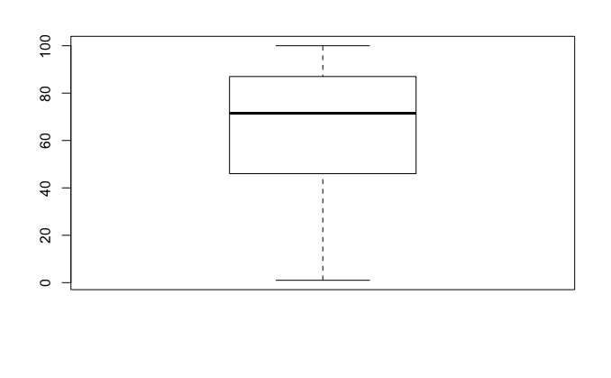

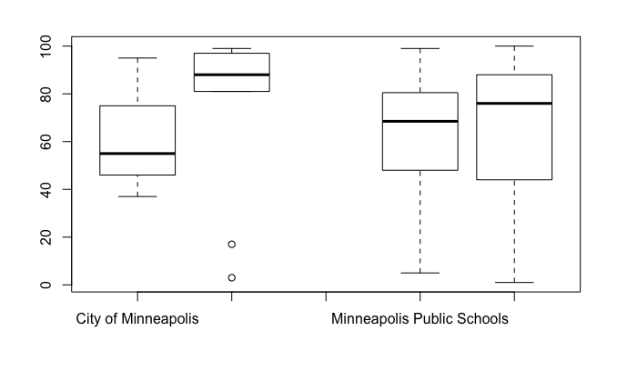

Where missing some labels! Lets try this again! (where did I find this information? I googled it: https://www.statmethods.net/advgraphs/parameters.html)

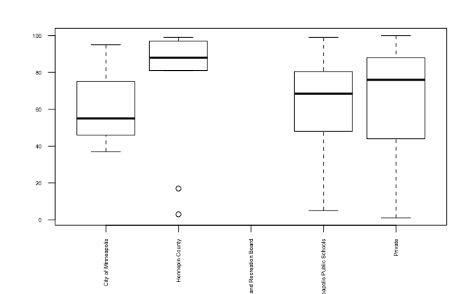

## GGPlot

- [GGPlot](https://ggplot2.tidyverse.org/reference/ggplot.html)
- [GGPlot Cheatsheet](https://www.rstudio.com/wp-content/uploads/2015/03/ggplot2-cheatsheet.pdf)

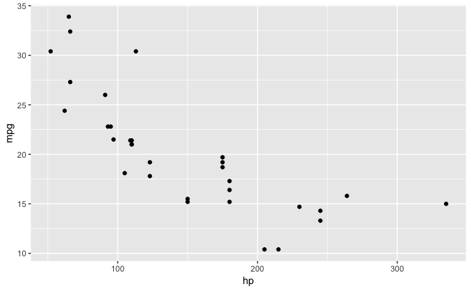

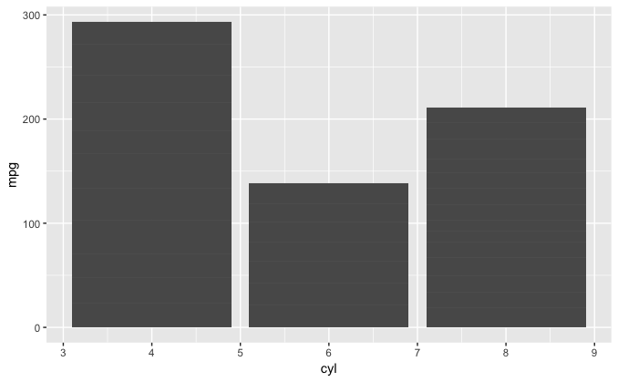

```r
ggplot(cardata, aes(y=mpg,x=cyl)) +
  geom_bar(stat="identity")
```

What else should we do?

# Getting data out of R

## Export a dataset to a CSV file

```r
write.csv(data, "data.csv")
```